# 6.1. Applications

# 6.1.1. Bay Area Bike Share Data

The [Bay Area Bike share](https://www.fordgobike.com/system-data) program has an open data portal that has a large amount of anonymized data on bike trips taken by users of he program. The data is quite clean, but still affords a nice opportunity to make sense of it. There are many questions we can ask, but we will just focus on computing some basic summaries on the data. This will offer a good opportunity to use the facilities offered by `dplyr`, for example.

The data set is reasonably large and so we want to avoid any unnecessary processing, unless absolutely essential. So we will use the `readr::read_csv` to import the data.

The main datasets of interest to us, per the README.txt file included with the data are:

1. The Station Information (file `201508_station_data.csv`)
2. The Trip data (file `201508_trip_data.csv`)
3. The Weather data (file `201508_weather_data.csv`)

# 6.1.2. Read the data into R

We first deal with the station data:

```r
library(readr)
stationData <- read_csv("babs/201508_station_data.csv")
```

We want to know how many stations there are, how many cities, how many docks per city etc.

# 6.1.2. How many stations?

```r
library(dplyr)
## How many stations?
stationData %>% nrow
```

```
## [1] 70
```

# 6.1.3. How many cities in the Bay area participate?

```r
## How many cities
stationData %>%
    distinct(landmark)
```

```
## # A tibble: 5 x 1
##   landmark
##   <chr>
## 1 San Jose
## 2 Redwood City
## 3 Mountain View
## 4 Palo Alto
## 5 San Francisco
```

# 6.1.4. How many docks are available per city?

```r
## How many docks per city
stationData %>%
    group_by(landmark) %>%
    summarize(count = n())
```

```
## # A tibble: 5 x 2
##   landmark      count
##   <chr>         <int>
## 1 Mountain View     7
## 2 Palo Alto         5
## 3 Redwood City      7
## 4 San Francisco    35
## 5 San Jose         16
```

We turn our attention to the trip data.

Below, we provide better names (with no spaces) and specify how the date values should be parsed. We only need to provide the information for those types that are not detected correctly; for us, just the dates.

```r
read_csv("babs/201508_trip_data.csv",
         col_names = c("TripId", "Duration", "StartDate", "StartStation",
                       "StartTerminal", "EndDate", "EndStation", "EndTerminal",
                       "BikeNo", "SubscriberType", "ZipCode"),
         skip = 1,
         col_types = cols(
             StartDate = col_datetime( format = "%m/%d/%Y %H:%S"),
             EndDate = col_datetime( format = "%m/%d/%Y %H:%S")
         )) ->
    tripData
tibble::glimpse(tripData)
```

```
## Observations: 354,152
## Variables: 11
## $ TripId         <dbl> 913460, 913459, 913455, 913454, 913453, 913452, 913451…
## $ Duration       <dbl> 765, 1036, 307, 409, 789, 293, 896, 255, 126, 932, 691…
## $ StartDate      <dttm> 2015-08-31 23:00:26, 2015-08-31 23:00:11, 2015-08-31 …
## $ StartStation   <chr> "Harry Bridges Plaza (Ferry Building)", "San Antonio S…
## $ StartTerminal  <dbl> 50, 31, 47, 10, 51, 68, 51, 60, 56, 47, 60, 67, 76, 77…
## $ EndDate        <dttm> 2015-08-31 23:00:39, 2015-08-31 23:00:28, 2015-08-31 …
## $ EndStation     <chr> "San Francisco Caltrain (Townsend at 4th)", "Mountain …
## $ EndTerminal    <dbl> 70, 27, 64, 8, 60, 70, 60, 74, 55, 66, 77, 70, 73, 82,…
## $ BikeNo         <dbl> 288, 35, 468, 68, 487, 538, 363, 470, 439, 472, 434, 5…
## $ SubscriberType <chr> "Subscriber", "Subscriber", "Subscriber", "Subscriber"…
## $ ZipCode        <chr> "2139", "95032", "94107", "95113", "9069", "94118", "9…
```

We are now in better shape to answer some questions.

# 6.1.4. How many trips in the data set?

An obvious try is:

```r
tripData %>%
    nrow
```

```
## [1] 354152
```

A more defensive and safer thing to do is to use `TripId` since it is guaranteed to be distinct for each trip. We do that below, but it makes no difference here.

```r
tripData %>%
    distinct(TripId) %>%
    nrow
```

```
## [1] 354152
```

# 6.1.5. What period does this dataset cover?

```r
tripData %>%
    summarize(start = as.Date(min(StartDate)), end = as.Date(max(EndDate)))
```

```
## # A tibble: 1 x 2
##   start      end
##   <date>     <date>
## 1 2014-09-01 2015-08-31
```

# 6.1.6. What was the total amount of riding time in years?

```r
tripData %>%
    summarize(total = ((sum(Duration) / 3600) / 24) / 365)
```

```
## # A tibble: 1 x 1
##   total
##   <dbl>
## 1  11.7
```

# 6.1.7. Busiest and Slowest days

We first create a `tripCount` data set to work with.

```r
tripData %>%
    mutate(Date = as.Date(StartDate)) %>%
    group_by(Date) %>%
    summarize(trips = n()) ->
    tripCounts
```

Let us print the first few rows to see what this looks like.

```r
tripCounts %>% print(n = 20)
```

```
## # A tibble: 365 x 2
##    Date       trips
##    <date>     <int>
##  1 2014-09-01   368
##  2 2014-09-02  1319
##  3 2014-09-03  1404
##  4 2014-09-04  1389
##  5 2014-09-05  1265
##  6 2014-09-06   435
##  7 2014-09-07   336
##  8 2014-09-08  1305
##  9 2014-09-09  1362
## 10 2014-09-10  1351
## 11 2014-09-11  1381
## 12 2014-09-12  1308
## 13 2014-09-13   556
## 14 2014-09-14   435
## 15 2014-09-15  1516
## 16 2014-09-16  1438
## 17 2014-09-17  1429
## 18 2014-09-18  1186
## 19 2014-09-19  1245
## 20 2014-09-20   427
## # … with 345 more rows
```

Now we can compute the busiest and slowest days, respectively

```r
tripCounts %>%
    arrange(desc(trips)) %>%
    filter(row_number() == 1 | row_number() == n())
```

```
## # A tibble: 2 x 2
##   Date       trips
##   <date>     <int>
## 1 2014-09-15  1516
## 2 2014-12-11   107
```

We can further add information on what day of the week it was for some insight. This requires figuring out the day of the week given a date.

The R function `base::weekdays` will compute the day of the week for any proper date.

```r
tripCounts %>%
    arrange(desc(trips)) %>%
    filter(row_number() == 1 | row_number() == n()) %>%
    mutate(WeekDay = base::weekdays(Date))
```

```
## # A tibble: 2 x 3
##   Date       trips WeekDay
##   <date>     <int> <chr>
## 1 2014-09-15  1516 Monday
## 2 2014-12-11   107 Thursday
```

# 6.1.8. How many rides per week day, on average? How many per weekend day?

We ignore holidays. We need a way to detect weekend or not, which is now easy using the day of the week. Let us create a new trip count data set with these variables.

```r
tripData %>%
    mutate(Date = as.Date(StartDate),
           DayOfWeek = base::weekdays(Date),
           Weekend = DayOfWeek %in% c("Saturday", "Sunday")) %>%
    group_by(Date, Weekend) %>%
    summarize(trips = n()) ->
    tripCounts2
```

So now we have a new variable that tells us whether we have a weekend or not.

```r
tibble::glimpse(tripCounts2)
```

```
## Observations: 365
## Variables: 3
## Groups: Date [365]
## $ Date    <date> 2014-09-01, 2014-09-02, 2014-09-03, 2014-09-04, 2014-09-05, …
## $ Weekend <lgl> FALSE, FALSE, FALSE, FALSE, FALSE, TRUE, TRUE, FALSE, FALSE, …
## $ trips   <int> 368, 1319, 1404, 1389, 1265, 435, 336, 1305, 1362, 1351, 1381…
```

Computing the average rides per weekday and weekends is now a straightforward summarization.

```r
tripCounts2 %>%
    group_by(Weekend) %>%
    summarize(avgTrips = mean(trips))
```

```
## # A tibble: 2 x 2
##   Weekend avgTrips
##   <lgl>      <dbl>
## 1 FALSE      1213.
## 2 TRUE        362.
```

# 6.1.9. Example from survival analysis (SEER)

If you go to [Cancer Center Statistics](http://www.cancercenter.com/breast-cancer/statistics/tab/breast-cancer-survival-statistics/) Cancer Centers of America website for example, you will see some comparison as to how their hospitals do regarding survival rates for various cancers They compare, for example, their survival rates to national rates using data from the [Surveillance, Epidemiology and End Results](https://seer.cancer.gov/registries/) (SEER) database. Five-year survival statistics are common.

__The Problem__To construct statistical summaries to compare how our Cancer center compares to national statistics.

One can request the SEER data and combine it with local data to do the comparison._The SEER data is large!_ Over 2 million rows containing over 40 variables, including survival time.

**NOTE** Due to restrictions on SEER data, I am unable to distribute this data for the class. However, here is the production code we actually use for doing this comparison.

# 6.1.10. Data Ingestion and Preparation

First, the preamble, which loads libraries, reads the data and ensures that we don’t process data more often than necessary.

```r
library('survival')
library(ggplot2)
library(GGally)
library(magrittr)
library(dplyr)
library(readr)

## CUSTOMIZE CUTOFF YEARS HERE. These are varied for different years!
startYear <- 2005
splitYear <- 2008
currentSeerYear <- 2012
seerdataFile <- "seerdata.gzip"
stanfordFile <- "localdata.tsv"  ## actually in a database!
```

Next the code for processing the data.

```r
seer <- readr::read_table(file = seerdataFile, col_names = TRUE,
                   na = c("Blank(s)", "N/A"))
stanford <- readr::read_table(file = stanfordFile, col_names = TRUE)
```

# 6.1.11. Data Filtering and Transformations

Below, we go through several steps.

```r
seer %>%
    ## Select only relevant year data on primary malignancies
    filter(
        SEX %in% c("Male", "Female"),
        FIRST_MALIG_PRIMARY == "Yes",
        SEQUENCE_NUMBER %in% c("One primary only"),
        DX_CONFIRMATION != "Unconfirmed",
        DX_YR >= startYear,
        DX_YR <= currentSeerYear,
        SURVIVAL_MONTHS_PRESUME_ALIVE < 400
    ) %>%
    ## Recode some variables and create new ones
    mutate(
        id = PATIENT_ID,
        dx_yr = DX_YR,
        site_code = substr(PRIMARY_SITE_LABEL, 1, 5),
        hist_code = HIST_TYPE_CODE,
        stage = ifelse(is.na(DERIVED_AJCC_STG_6), DERIVED_AJCC_STG_7, DERIVED_AJCC_STG_6),
        time = as.numeric(SURVIVAL_MONTHS_PRESUME_ALIVE),
        event = ifelse(VITAL_STATUS_RECODE == "Dead", 1, 0)
    ) %>%
    mutate(
        STG4 = as.integer(grepl("^IV", stage)),
        STG3 = as.integer(grepl("^III", stage)),
        STG2 = as.integer(grepl("^II", stage)),
        STG1 = as.integer(grepl("^I", stage)),
        STG0 = as.integer(grepl("^0", stage))
    ) %>%
    ### More stuff
    mutate(
        simple_stg = ifelse(SIMPLE_STG == 0, NA, SIMPLE_STG - 1),
        source = "SEER"
    ) %>%
    ## Select only variables of interest to us
    select(source, dx_yr, site_code, hist_code, stage, time, event, simple_stg) ->
    seerData
```

Do the same for Stanford data, slightly different from SEER.

```r
stanford %>%
    filter(
        SEX %in% c("Male", "Female"),
        FIRST_MALIG_PRIMARY == "Yes",
        SEQUENCE_NUMBER %in% c("One primary only"),
        DX_CONFIRMATION != "Unconfirmed",
        DX_YR >= startYear,
        DX_YR <= currentSeerYear,
        DX_AGE_RECODE >= 19
    ) %>%
    mutate(
        id = PATIENT_ID,
        dx_yr = DX_YR,
        site_code = PRIMARY_SITE_CODE,
        hist_code = HIST_TYPE_CODE,
        stage = DERIVED_AJCC_STG_7,
        time = SURVIVAL_MONTHS_PRESUME_ALIVE,
        event = ifelse(VITAL_STATUS_RECODE == "Dead", 1, 0)
    ) %>%
    mutate(
        STG4 = as.integer(grepl("^IV", stage)),
        STG3 = as.integer(grepl("^III", stage)),
        STG2 = as.integer(grepl("^II", stage)),
        STG1 = as.integer(grepl("^I", stage)),
        STG0 = as.integer(grepl("^0", stage))
    ) %>%
    ### More stuff
    mutate(
        simple_stg = ifelse(SIMPLE_STG == 0, NA, SIMPLE_STG - 1),
        source = "STANFORD"
    ) %>%
    select(source, dx_yr, site_code, hist_code, stage, time, event, simple_stg) ->
    suData
```

Combine the entire dataset into one

```r
allData <- rbind(seerData, suData)
```

# 6.1.12. Focus on one cancer

Each cancer has a set of ICD codes and histology codes corresponding to it. For example, for breast cancer, it is

```r
icdCodes <- c("C50.0", "C50.1", "C50.2", "C50.3", "C50.4", "C50.5", "C50.6",
              "C50.7", "C50.8", "C50.9");
histCodes <- c(seq(8000, 8231), seq(8250, 8575));
cancerType <- "Breast Cancer"
```

Our goal is to generate a report for each cancer and so we need a helper function.

```r
#' Generate report for one cancer
#' @param icdCodes the ICD codes for the cancer of interest
#' @param histCodes the histology codes for the cancer of interest
#' @param cancerName the cancer name as a string
#' @param ci flag to denote if confidence interval desired or not, default FALSE
#' @param plot.cems should the censored observations be plotted? Default FALSE
#' @return a named list of items
#'  \describe{
#'     \item{suSummary}{Stanford data frame of summary counts}
#'     \item{barPlot}{A ggplot barplot object of frequency of cases by year}
#'     \item{survFits}{a list of four survival fit objects, one per stage I, II, II, IV}
#'     \item{survPlots}{a list of four ggplot survival plot objects, one per stage I, II, II, IV}
#'     \item{overallFit}{An overall surivival fit object}
#'     \item{overallPlot}{An overall survival ggplot object}
#'
doOneCancer <- function(icdCodes = NULL, histCodes = NULL, cancerName,
                        ci = FALSE, plot.cens = FALSE, ...) {
    d <- if (is.null(icdCodes) && is.null(histCodes)) {
        allData
    } else if (is.null(icdCodes)) {
        filter(allData, hist_code %in% histCodes)
    } else {
        filter(allData, site_code %in% icdCodes)
    }
    ## Summarize Local Data
    suSummary <-
        d %>%
        filter(source == "STANFORD") %>%
        group_by(dx_yr) %>%
        summarize(count = n())

    g <- ggplot(data = suSummary, aes(x = dx_yr, y = count)) +
        geom_bar(stat = "identity" )

    ## Do for each stage 0, 1, 2, 3, 4
    fits <- lapply(0:4,
                   function(x) {
                       subData <- d %>%
                           filter(simple_stg == x)
                       if (nrow(subData) > 0) {
                           survfit(Surv(time, event) ~ source, data = subData)
                       } else {
                           NULL
                       }
                   })

    plots <- lapply(0:4,
                    function(x) {
                        obj <- fits[[x + 1]]
                        if (!is.null(obj)) {
                            ggsurv(fits[[x + 1]], xlab = "Months Post-Dx", ylab = "Survival",
                                   main = sprintf("%s survival (stage %d)", cancerName, x),
                                   plot.cens = FALSE, CI = FALSE, ...) +
                                xlim(0, 125) + ylim(0, 1)
                        } else {
                            NULL
                        }
                    })

    overallFit <- survfit(Surv(time, event) ~ source, data = d)
    overallPlot <- ggsurv(overallFit, xlab = "Months Post-Dx", ylab = "Survival",
                          main = sprintf("%s survival (all stages)", cancerName),
                          plot.cens = FALSE, CI = FALSE, ...) +
        xlim(0, 125) + ylim(0, 1)

    list(suSummary = suSummary, barPlot = g, survFits = fits, survPlots = plots,
         overallFit = overallFit, overallPlot = overallPlot)
}
```

Once we have this, all we have to do is invoke it.

```r
result <- doOneCancer(icdCodes, histCodes, cancerType)
```

We can then print summaries, plots etc. easily as follows

```r
#### Stanford Summary
result$suSummary
## Bar plot of cases
result$barPlot
## Stage 0
result$survPlots[[1]]
#### Stage 1
result$survPlots[[2]]
#### Stage 2
result$survPlots[[3]]
#### Stage 3
result$survPlots[[4]]
#### Stage 4
result$survPlots[[5]]
```

In our actual production system, our R code uses these functions to generate markdown which is `rendered` into a report.

# 6.1.12. Some screenshots

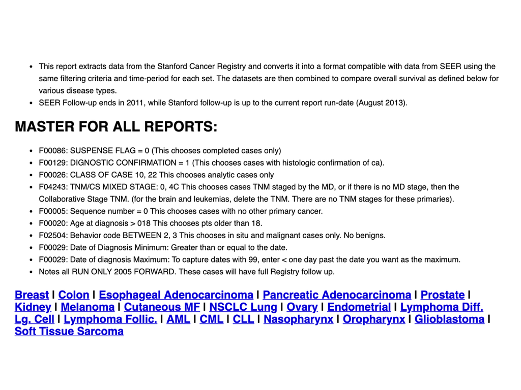

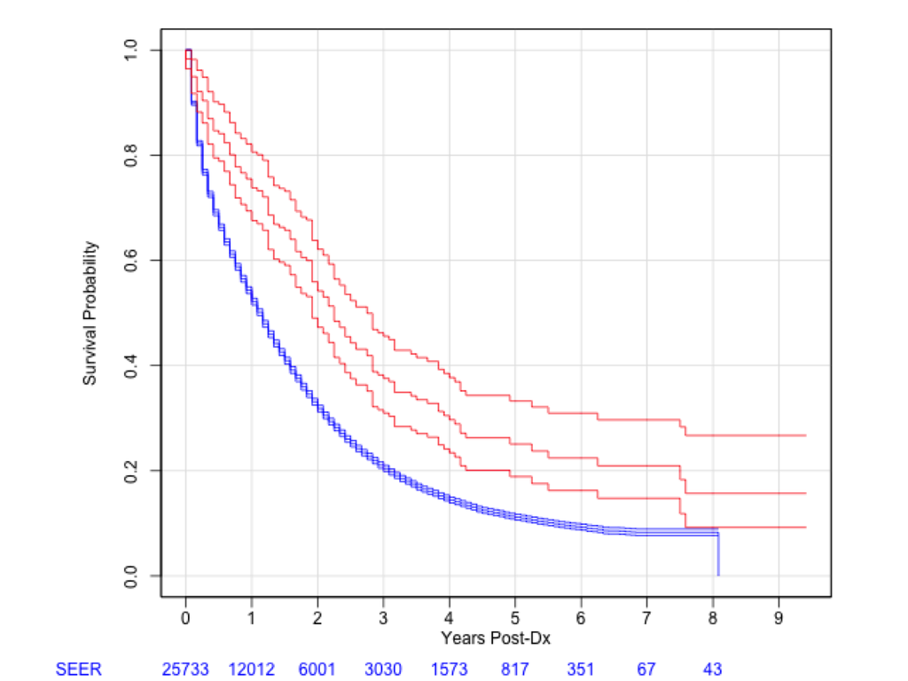